# Active-power forecasting project

Yu Wang

## Introduction(Business Scenario)

Renewable energy remains one of the most important topics for a sustainable future. Wind is one of the primary sources of renewable energy. ( https://www.energy.gov/eere/wind/how-do-wind-turbines- work). With the rise of wind farms, wind power forecasting has become an important topic. Utility companies need accurate forecasts of the amount of power being produced by wind turbines in order to ensure that they have sufficient power available to meet demand. The attached data set contains information associated with a single wind turbine. The data were collected at 10-minute intervals. The variables included in the data set are summarized below.

Objective : Create a DAILY forecast for Active Power generation for the turbine for the next 5 day period (March 31 – April 4, 2020).

## Introduction(Business Scenario )

Date : Date/Time Stamp for each observation Year : Year portion of Date Month: Month portion of Date Day : Day portion of Date ActivePower: Active power generated by the wind turbine in kW. Note that active power can be negative. This occurs when the turbine is absorbing power from the grid. AmbientTermperature: Ambient air temperature in degrees Celsius WindDirection: Wind direction in degrees from the North WindSpeed: Wind speed in kmph

## Load Libraries

```r
library(tidyverse)
library(tidymodels)
library(janitor)
library(skimr)
library(kableExtra)
library(GGally)
library(vip)
library(fastshap)
library(MASS)
library(ISLR)
library(tree)
library(ggplot2)
library(dplyr)
library(lubridate)
library(imputeTS)
library(forecast)
library(urca)
library(pracma)
library(astsa)
library(fpp2)
library(reshape2)
```

# Import your data with read_csv()

```r
turbine <- read_csv("Turbine.csv") %>%
  clean_names()
```

## Exploring the Dataset

```r
turbine %>%
  skim_without_charts()
```

Data summary

| Name | Piped data |
| --- | --- |
| Number of rows | 118224 |
| Number of columns | 8 |
| _______________________ |  |
| Column type frequency: |  |
| numeric | 7 |
| POSIXct | 1 |
| ________________________ |  |
| Group variables | None |

**Variable type: numeric**

| skim_variable | n_missing | complete_rate | mean | sd | p0 | p25 | p50 | p75 | p100 |
| --- | --- | --- | --- | --- | --- | --- | --- | --- | --- |
| year | 0 | 1.00 | 2018.66 | 0.67 | 2017.00 | 2018.00 | 2019.00 | 2019.00 | 2020.00 |
| month | 0 | 1.00 | 6.04 | 3.56 | 1.00 | 3.00 | 6.00 | 9.00 | 12.00 |
| day | 0 | 1.00 | 15.72 | 8.79 | 1.00 | 8.00 | 16.00 | 23.00 | 31.00 |
| active_power | 23474 | 0.80 | 619.11 | 611.28 | -38.52 | 79.64 | 402.65 | 1074.59 | 1779.03 |
| ambient_temperature | 24407 | 0.79 | 28.77 | 4.37 | 0.00 | 25.63 | 28.34 | 31.66 | 42.41 |
| wind_direction | 45946 | 0.61 | 196.29 | 88.30 | 0.00 | 145.00 | 182.00 | 271.00 | 357.00 |
| wind_speed | 23629 | 0.80 | 5.88 | 2.62 | 0.00 | 3.82 | 5.56 | 7.51 | 22.97 |

**Variable type: POSIXct**

| skim_variable | n_missing | complete_rate | min | max | median | n_unique |
| --- | --- | --- | --- | --- | --- | --- |
| date | 0 | 1 | 2017-12-31 | 2020-03-30 23:50:00 | 2019-02-14 11:55:00 | 118224 |

```r
## Active_power has some missing data we need to figure out a way to impute those
# dataset has100+ row of data and 8 columns
```

## Data imputation with na_kalman (good way to imputate data with trend and seasonlity)

```r
turbine$active_power <-na_kalman(turbine$active_power)
turbine$wind_speed<-na_kalman(turbine$wind_speed)

turbine
```

```
## # A tibble: 118,224 × 8
##     year month   day date                active_power ambient_temperature
##    <dbl> <dbl> <dbl> <dttm>                     <dbl>               <dbl>
##  1  2017    12    31 2017-12-31 00:00:00        -5.36                  NA
##  2  2017    12    31 2017-12-31 00:10:00        -5.36                  NA
##  3  2017    12    31 2017-12-31 00:20:00        -5.36                  NA
##  4  2017    12    31 2017-12-31 00:30:00        -5.36                  NA
##  5  2017    12    31 2017-12-31 00:40:00        -5.36                  NA
##  6  2017    12    31 2017-12-31 00:50:00        -5.36                  NA
##  7  2017    12    31 2017-12-31 01:00:00        -5.36                  NA
##  8  2017    12    31 2017-12-31 01:10:00        -5.36                  NA
##  9  2017    12    31 2017-12-31 01:20:00        -5.36                  NA
## 10  2017    12    31 2017-12-31 01:30:00        -5.36                  NA
## # … with 118,214 more rows, and 2 more variables: wind_direction <dbl>,
## #   wind_speed <dbl>
```

## Correlation Matrix Between the Variables to find the relation between the active generation and other numeric variables in the dataset

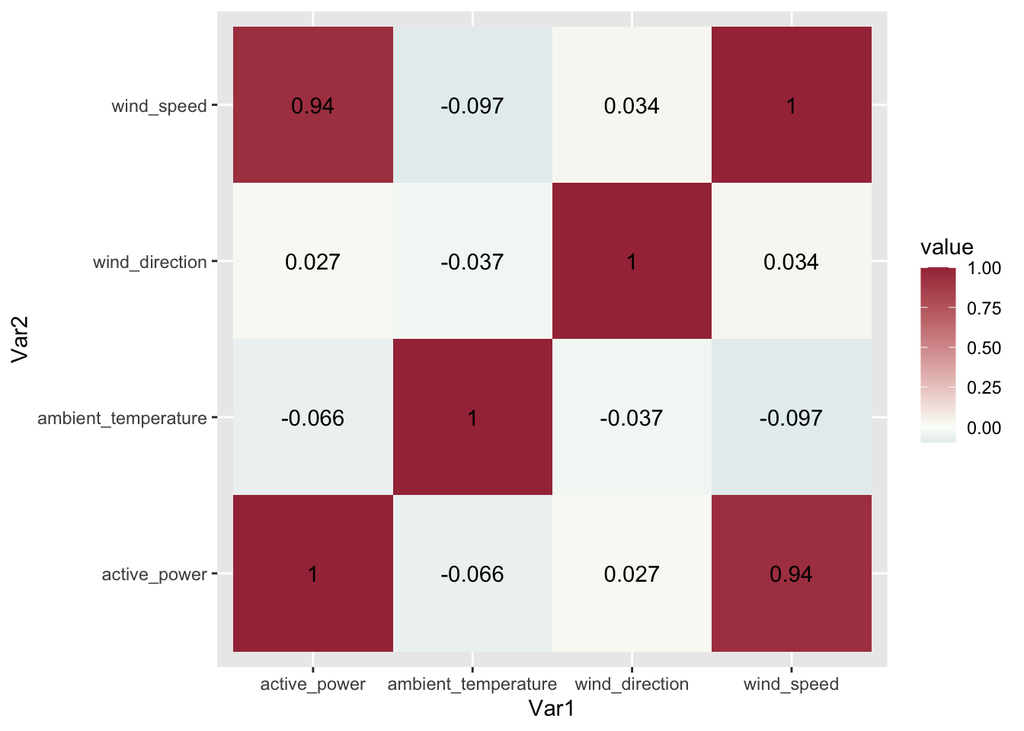

```r
numeric_col <- c("active_power", "ambient_temperature", "wind_direction", "wind_speed")

## create numeric_col
turbine %>%
  dplyr::select(all_of(numeric_col)) %>%
  na.omit() %>%
  cor() %>%
  melt %>%
  ggplot(aes(x=Var1, y=Var2, fill=value)) +
  geom_tile() +
  scale_fill_gradient2(mid="#FBFEF9",low="#0C6291",high="#A63446") +
  geom_text(aes(label=round(value, 3)), color="black")
```

## Data Transformation/Aggregation for the total_power and average wind speed

```r
options(scipen = 999)

turbine %>%
  group_by(year, month, day) %>%
  summarise(total_power = round(sum(active_power, na.rm = TRUE),2),
            avg_wind_speed = round(mean(wind_speed, na.rm = TRUE), 2)) %>%
  filter(year != 2017) -> turbine_data_transformed

#filter the values of 2017 as there are missing values for the entire year and it's the starting of the values. Therefore, it is better to remove missing values at the starting of the dataset.

turbine_data_transformed
```

```
## # A tibble: 820 × 5
## # Groups:   year, month [27]
##     year month   day total_power avg_wind_speed
##    <dbl> <dbl> <dbl>       <dbl>          <dbl>
##  1  2018     1     1      27576.           3.88
##  2  2018     1     2      48502.           4.67
##  3  2018     1     3      45893.           4.52
##  4  2018     1     4      51954.           5.06
##  5  2018     1     5      34469.           4.41
##  6  2018     1     6      19570.           3.86
##  7  2018     1     7      51211.           5.25
##  8  2018     1     8     109442.           6.72
##  9  2018     1     9      73008.           5.65
## 10  2018     1    10      63902.           5.39
## # … with 810 more rows
```

## Create time series object and impute the missing values in the time series object